# Sensory contributions I: Proprioception

KINESIOL 2MC3

Mike Carter, Ph.D.

cartem11@email.com

Department of Kinesiology | McMaster University

September 17 2025

## Last class

## Review: Attention and performance

- Understand properties of attention
- Explain how researchers can assess the attentional demands of a motor skill
- Describe how attention can limit information-processing activities
- Explain how attention influences the capability to perform actions

TAKE-HOME MESSAGE:  
Many factors influence how attention and arousal impact skilled motor performance.

## Lecture objectives

- Understand the role of sensory feedback in voluntary action
- Identify and describe types of sensory information important for skilled performance
- Describe different tests that can be used to investigate the role of kinesthesis/proprioception in motor control
- Describe how voluntary motor control is impacted by the loss of proprioception

TAKE-HOME MESSAGE:  
Sensory feedback is critical for skilled voluntary actions.

## Sensory information

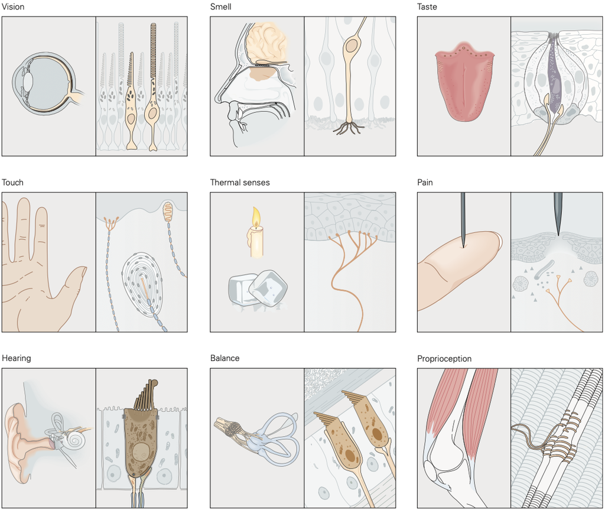

Image from Kandel et al. (2021)

## Sensory receptors respond to stimulation

Sensory receptors in the human body respond to four basic kinds of energy:

1. **PHOTORECEPTOR:** primarily responsive to light
2. **MECHANORECEPTOR:** primarily responsive to mechanical energy
   - e.g., vestibular receptors, touch receptors
3. **CHEMORECEPTORS:** primarily responsive to certain chemical substances
   - e.g., taste receptors, smell receptors
4. **THERMORECEPTORS:** primarily responsive to thermal energy

## Classifying sensory receptors

- **EXTEROCEPTORS:** respond to mechanical, chemical, thermal, or electromagnetic contact with the **external environment**
  - e.g., mechanoreceptors in the skin, photoreceptors, etc.
- **INTEROCEPTORS:** respond to stimulation produced by physiological processes **within the body**
  - e.g., thermoreceptors within deep tissues that respond to internal body temperature, mechanoreceptors in arterial walls, etc.
- **PROPRIOCEPTORS:** respond to **mechanical stimulation** associated with
  - the angular position of joints, movement of joints
  - the orientation of body segments
  - tension in ligaments, tendons, and other connective tissues
  - muscle length, and changes in muscle length

## Sensation versus perception

- **sensing** is what sensory receptors do: transduce stimulus energy into electrical signals
  - sensation usually refers to the conscious feeling associated with sensing
- **perception** is about **obtaining useful information** from sensory stimulation and **making it available** for
  - decision-making
  - planning and controlling motor actions
  - for communication
  - skill acquisition and refinement
  - etc.

## The hand has 4 types of mechanoreceptors

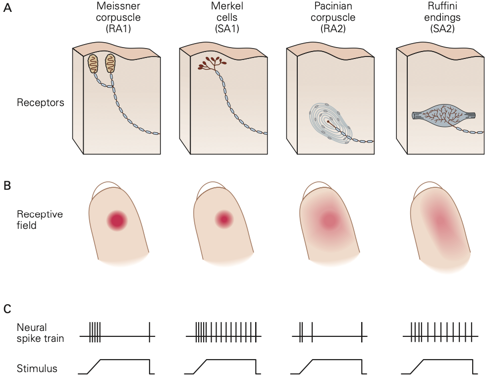

Image from Kandel et al. (2021)

## The hand has 4 types of mechanoreceptors

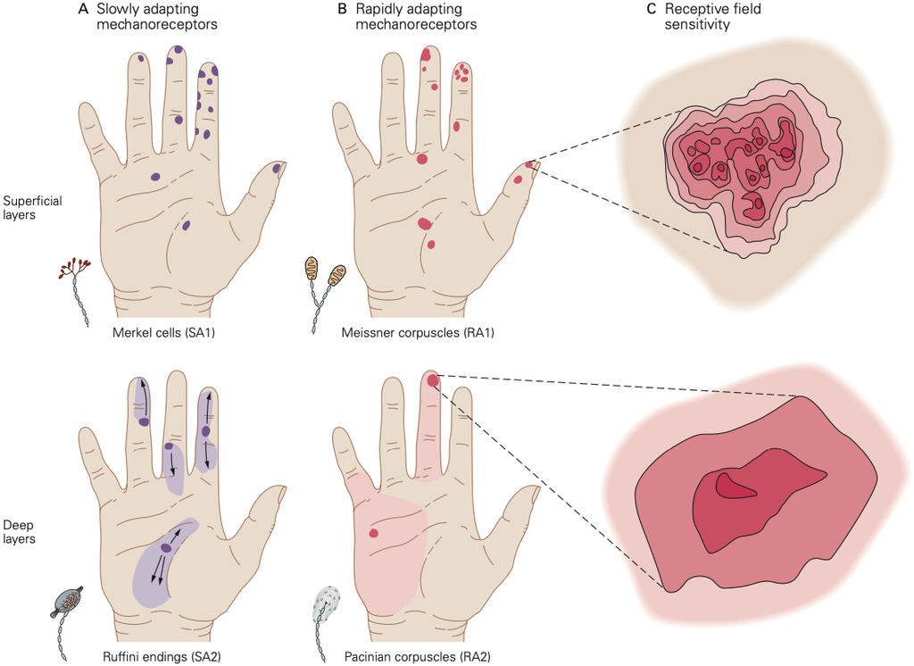

Image from Kandel et al. (2021)

## Tactile information is critical for dextrous behaviour

**Normal; Full vision**

[video not shown]

**Fingertip anesthesia; Full vision**

[video not shown]

Left: https://youtu.be/zGIDptsNZMo; Right: https://youtu.be/HH6QD0MgqDQ

## Kinesthesis and proprioception

- afferent signals generated by exteroceptors in response to external stimulation is **exteroceptive afference**
  - contains information about external objects, substances, and events
- afferent signals generated by somatosensory mechanoreceptors in response to internal stimulation is **proprioceptive afference**
- **KINESTHESIS:** the perception of body position and movement from proprioceptive afference
- **PROPRIOCEPTION:** a general term for perception based on proprioceptive afference that includes the perception of muscular effort and force

## Proprioception

- sensory information from the motor periphery is critical for skilled actions
- we rely on proprioceptive information from a variety of receptors:
  - muscle spindles
  - golgi tendon organs
  - joint-capsule receptors
  - Ruffini endings
- muscle spindles and golgi tendon organs are the main ones

## Muscle spindles are the principal receptor for proprioception

- muscle spindles are sensitive to **muscle stretch** and **rate of stretch**
- two types: Ia and II
- muscle spindle is located within skeletal muscle
- spindles fire when the muscle is lengthened and stop firing when the muscle is contracted

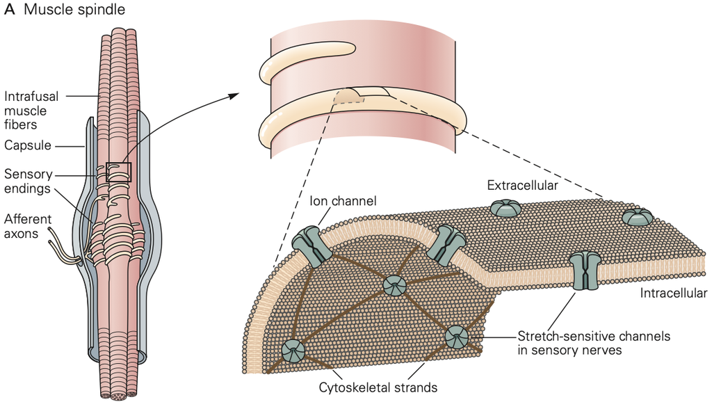

Image from Kandel et al. (2021)

## Muscle spindles are the principal receptor for proprioception

- receptor potential and firing rates of muscle spindle afferent fibers are **proportional to muscle length**
- but these responses **can be modulated** by higher brain areas
- this means spindle afferent fibers can **encode the amplitude and speed** of internally generated voluntary movements as well as passive limb displacement by external forces

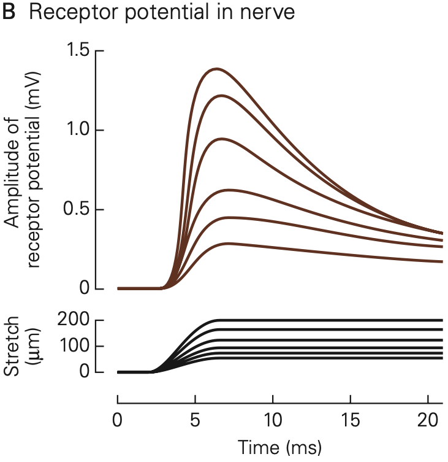

Image from Kandel et al. (2021)

## Golgi tendon organs are sensitive to muscle force

- sensory receptors embedded within the **musculotendon junction**
- muscle **contraction lengthens** the GTO causing shortening of **Ib afferent** and increase in firing

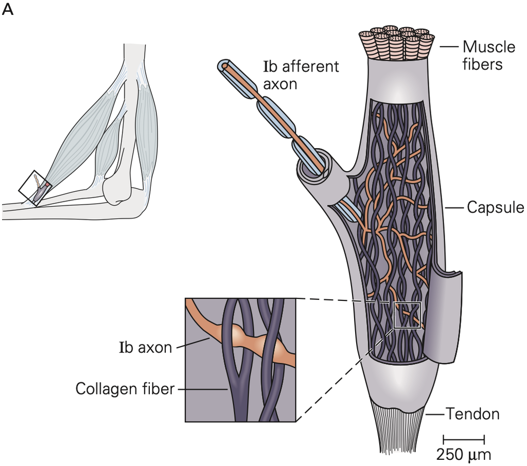

Image from Kandel et al. (2021)

## Golgi tendon organs are sensitive to muscle force

- sensory receptors embedded within the **musculotendon junction**
- muscle **contraction lengthens** the GTO causing shortening of **Ib afferent** and increase in firing
- GTO discharge rate is **proportional** to the force of muscle contraction
- force will only be applied when muscle fibers are **actively** developing force

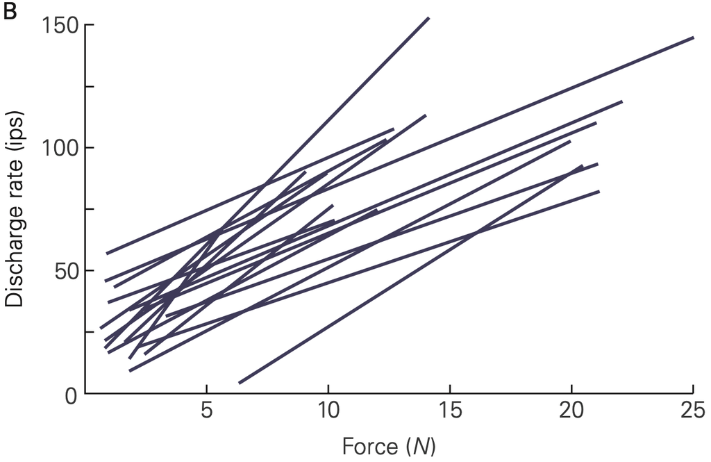

Image from Kandel et al. (2021)

## Assessing kinesthetic/proprioceptive acuity

- **MATCHING TASKS:** try to match position or movement of a body segment (the target) with something else
  - can be **simultaneous** or **successive**
- **DISCRIMINATION TASKS:** try to tell the difference between two or more situations
  - e.g., set joint angles for effectors and ask to judge whether one is more flexed/extended
  - can be used to establish a **discrimination threshold**

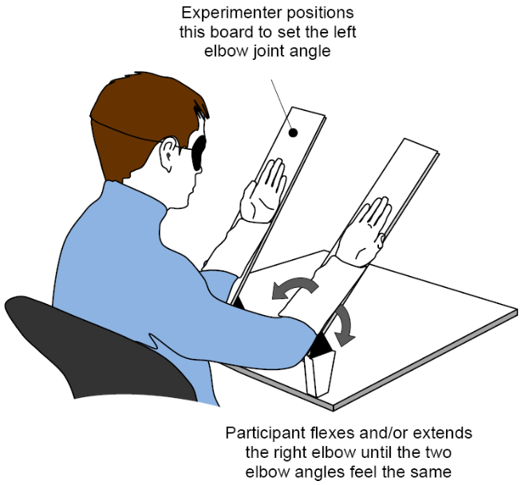

Image from Tresilian (2012)

## Assessing kinesthetic/proprioceptive acuity

[figure not shown]

## Assessing kinesthetic/proprioceptive acuity

**Healthy, age-matched control**

[video not shown]

**Patient that suffered a stroke**

[video not shown]

Videos from Kinarm (BKIN Technologies). Left: https://vimeo.com/800659690; Right: https://vimeo.com/800659701

## How well can healthy people kinesthetically localize a body part?

- **KINESTHETIC LOCALIZATION:** is studied using a task where a participant places a body part, usually a finger, in a target position
  - task can be **simultaneous** or **successive**
  - people’s ability to perform this task depends on:
    - where the body parts are in space
    - what body parts are involved
    - whether target is achieved passively or actively

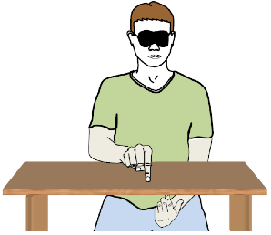

Image from Tresilian (2012)

## How well can healthy people kinesthetically localize a body part?

[figure not shown]

Image from Tresilian (2012) based on data from Haggard et al. (2000)

## Case studies - Living without proprioception

**Ginette Lizotte**

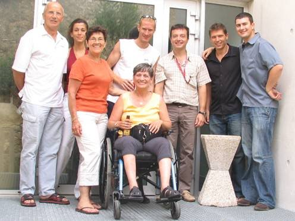

**Ian Waterman**

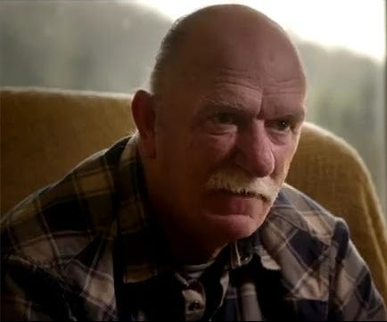

## Case studies - Living without proprioception

[video not shown]

Video link: https://youtu.be/kUsSU_MVYd8

## Case studies - Living without proprioception

**Eyes closed; Hold object**

[video not shown]

**Finger sequence task**

[video not shown]

Left: https://youtu.be/W3CLCVLq_CU; Right: https://youtu.be/B4Qs5wQTTec

## Case studies - Living without proprioception

**Pegboard task**

[video not shown]

**Reaching task**

[video not shown]

Left: https://youtu.be/QK0EryOV6LE; Right: https://youtu.be/Me0cBor6y-o

## Case studies - Living without proprioception

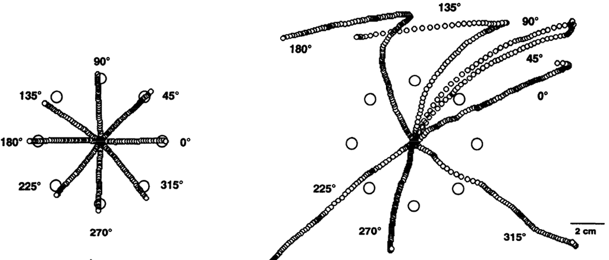

Figure from Gordon et al. (1995)

## What questions do you have?

[figure not shown]

*Next class: Sensory contributions II*

## References

**Gordon J**, **Ghilardi MF**, **Ghez C**. Impairments of reaching movements in patients without proprioception. I. Spatial errors. *Journal of neurophysiology* 73: 347–360, 1995.

**Haggard P**, **Newman C**, **Blundell J**, **Andrew H**. The perceived position of the hand in space. *Perception & Psychophysics* 62: 363–377, 2000.

**Kandel ER**, **Koester JD**, **Mack SH**, **Siegelbaum SA**, editors. *Principles of neural science*. 6th ed. New York: McGraw Hill, 2021.

**Tresilian J**. *Sensorimotor control and learning: An introduction to the behavioral neuroscience of action*. Bloomsbury Publishing, 2012.